# lab9

Shone George Kutty Renjan

2024-10-28

# Task

## Task 1

```r
getwd()
```

```
## [1] "/Users/shonerenjan/Desktop/ASM/Labs/lab9"
```

## Task 2

Line A draws a sample of size n*iter from x with replacement. Line B constructs a 100(1−𝛼)% confidence interval using xstat.

Replacement is necessary because the sample itself contains only n values. If we resample it without replacement, we would simply end up with the original sample.

### With Replacement

```r
set.seed(35)  # Gives everyone the same sample
sam=round(rnorm(20,mean=10,sd=4),2)
unique(sample(sam,20,replace=TRUE))
```

```
##  [1] 12.05 23.35 11.40 14.26  8.43 13.46  2.37  8.62 17.35 11.64 14.76  9.82
```

```r
unique(sample(sam, 20 ,replace=TRUE))
```

```
##  [1]  8.43 14.26  7.75  2.89 12.05  2.37  9.82 13.46  6.93 10.53 23.35 11.78
## [13]  8.62 11.40  9.86
```

```r
unique(sample(sam,20, replace=TRUE))
```

```
##  [1]  9.86 10.53 14.26 17.35 12.05  6.93 23.35  8.62 11.64 16.69 11.40
```

```r
unique(sample(sam,20,replace=TRUE))
```

```
##  [1] 11.64  9.82  8.62 17.35 11.78 11.40  7.75  2.37 23.35  2.89
```

```r
unique(sample(sam,20,replace=TRUE))
```

```
##  [1]  7.75 14.76 16.69 17.35 14.26  8.62 11.40  8.43 12.05  2.89 10.53 23.35
```

This displays unique sampling with replacement. We can clearly see that if there are fewer than 20 values, there is some repetition within that vector. The above are five vectors that represent sampling with replacement.

### Without Replacement

```r
set.seed(35) # This will give everyone the same sample
sam=round(rnorm(20,mean=10,sd=4),2)
unique(sample(sam,20,replace=FALSE))
```

```
##  [1] 12.05 23.35 11.40 17.35 14.26  8.43  8.62  2.89 16.69 10.53  8.00  6.93
## [13] 11.64  9.86  7.75 13.46 14.76  2.37  9.82 11.78
```

```r
unique(sample(sam,20,replace=FALSE))
```

```
##  [1]  8.43 14.76  9.82 16.69 11.64 14.26  7.75 12.05  8.00  8.62  2.37 10.53
## [13] 23.35 11.40 11.78  2.89  6.93 17.35  9.86 13.46
```

```r
unique(sample(sam,20,replace=FALSE))
```

```
##  [1]  2.89  9.86 10.53 14.26 17.35 12.05 11.40  6.93 23.35  2.37  8.62 11.78
## [13]  8.00 11.64 14.76  9.82 13.46 16.69  7.75  8.43
```

```r
unique(sample(sam,20,replace=FALSE) )
```

```
##  [1] 11.64 17.35 23.35 11.40 16.69  9.82  2.89 10.53  9.86 13.46  8.43  7.75
## [13]  8.00 14.76 11.78  8.62 12.05  2.37  6.93 14.26
```

```r
unique(sample(sam,20,replace=FALSE) )
```

```
##  [1] 11.78 16.69  2.37  8.62  7.75 12.05 14.76  9.82  9.86  8.00  2.89 14.26
## [13] 10.53 11.40  8.43 13.46 23.35 17.35 11.64  6.93
```

The above represents five vectors that involve sampling without replacement. Since we don’t replace the values after selecting them, once we choose a sample variable, there’s no way to choose it again. This concept is evident in the data provided, where each vector clearly contains all 20 possible values.

## Task 3

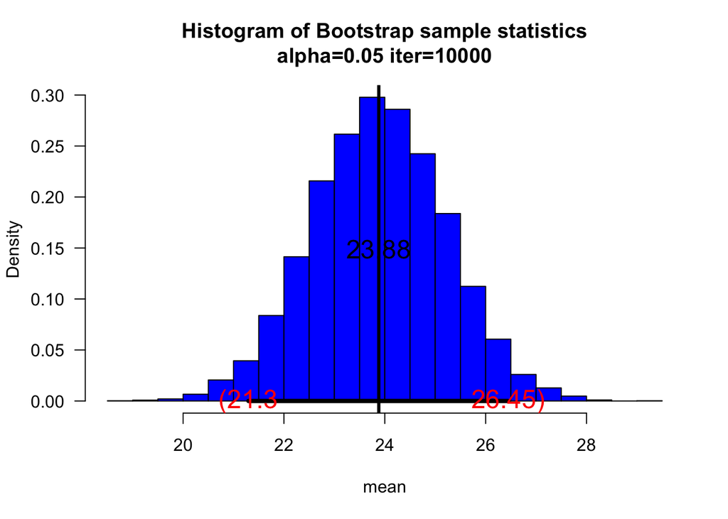

```r
myboot2<-function(iter=10000,x,fun="mean",alpha=0.05,cx=1.5,...){  #Notice where the ... is repeated in the code
n=length(x)   #sample size

y=sample(x,n*iter,replace=TRUE)
rs.mat=matrix(y,nr=n,nc=iter,byrow=TRUE)
xstat=apply(rs.mat,2,fun) # xstat is a vector and will have iter values in it
ci=quantile(xstat,c(alpha/2,1-alpha/2))# Nice way to form a confidence interval
# A histogram follows
# The object para will contain the parameters used to make the histogram
para=hist(xstat,freq=FALSE,las=1,
main=paste("Histogram of Bootstrap sample statistics","\n","alpha=",alpha," iter=",iter,sep=""),
...)

#mat will be a matrix that contains the data, this is done so that I can use apply()
mat=matrix(x,nr=length(x),nc=1,byrow=TRUE)

#pte is the point estimate
#This uses whatever fun is
pte=apply(mat,2,fun)
abline(v=pte,lwd=3,col="Black")# Vertical line
segments(ci[1],0,ci[2],0,lwd=4)      #Make the segment for the ci
text(ci[1],0,paste("(",round(ci[1],2),sep=""),col="Red",cex=cx)
text(ci[2],0,paste(round(ci[2],2),")",sep=""),col="Red",cex=cx)

# plot the point estimate 1/2 way up the density
text(pte,max(para$density)/2,round(pte,2),cex=cx)

invisible(list(ci=ci,fun=fun,x=x))# Some output to use if necessary
}

################### END mybooot function #####################

set.seed(39); sam=rnorm(25,mean=25,sd=10)
a=myboot2(iter=10000,sam,fun="mean",alpha=0.05, xlab="mean", col="blue")
```

```r
set.seed(30); sam=sam=rchisq(20,df=3)
b=myboot2(iter=10000,sam,fun="mean",alpha=0.05, xlab="mean", col="Green")
```

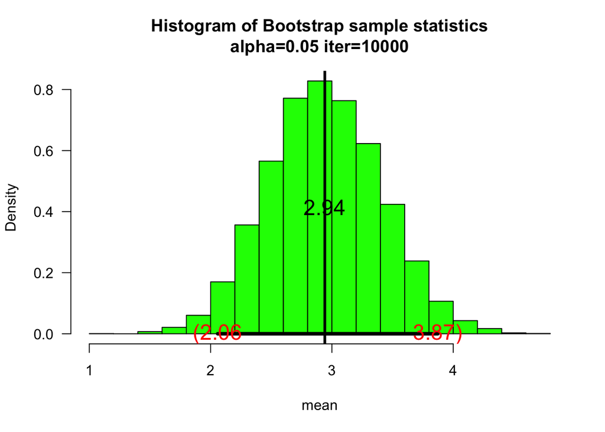

```r
set.seed(40); sam=rgamma(30,shape=2,scale=3)
c=myboot2(iter=10000,sam,fun="mean",alpha=0.05, xlab="mean", col="pink")
```

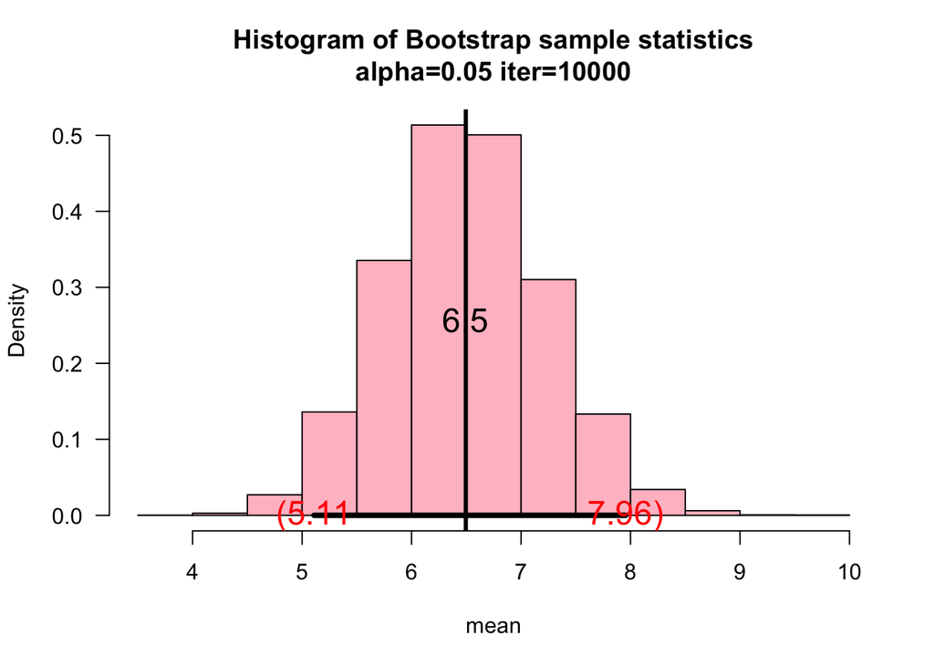

```r
set.seed(10); sam=rbeta(20,shape1=3,shape2=4)
d=myboot2(iter=10000,sam,fun="mean",alpha=0.05, xlab="mean", col="orange")
```

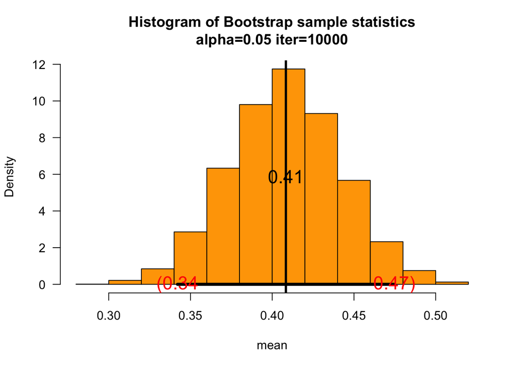

### Point Estimate to the Population Value

```r
qnorm(0.5,25,10)
```

```
## [1] 25
```

```r
qchisq(0.5,df=3)
```

```
## [1] 2.365974
```

```r
qgamma(0.5,shape=2,scale=4)
```

```
## [1] 6.713388
```

```r
qbeta(0.5,shape1=3,shape2=4)
```

```
## [1] 0.4214072
```

### Population Variance Plots

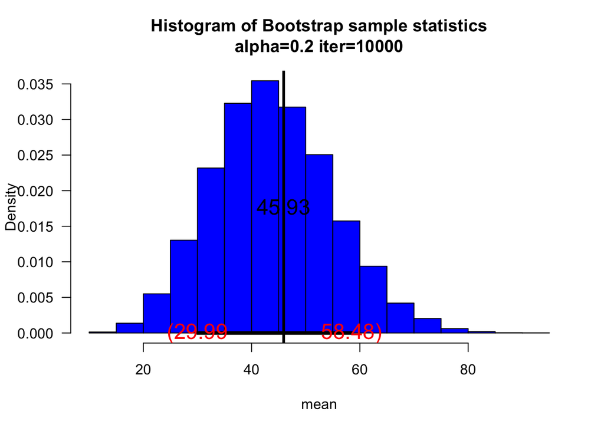

```r
myboot2<-function(iter=10000,x,fun="mean",alpha=0.05,cx=1.5,...){  #Notice where the ... is repeated in the code
n=length(x)   #sample size

y=sample(x,n*iter,replace=TRUE)
rs.mat=matrix(y,nr=n,nc=iter,byrow=TRUE)
xstat=apply(rs.mat,2,fun) # xstat is a vector and will have iter values in it
ci=quantile(xstat,c(alpha/2,1-alpha/2))# Nice way to form a confidence interval
# A histogram follows
# The object para will contain the parameters used to make the histogram
para=hist(xstat,freq=FALSE,las=1,
main=paste("Histogram of Bootstrap sample statistics","\n","alpha=",alpha," iter=",iter,sep=""),
...)

#mat will be a matrix that contains the data, this is done so that I can use apply()
mat=matrix(x,nr=length(x),nc=1,byrow=TRUE)

#pte is the point estimate
#This uses whatever fun is
pte=apply(mat,2,fun)
abline(v=pte,lwd=3,col="Black")# Vertical line
segments(ci[1],0,ci[2],0,lwd=4)      #Make the segment for the ci
text(ci[1],0,paste("(",round(ci[1],2),sep=""),col="Red",cex=cx)
text(ci[2],0,paste(round(ci[2],2),")",sep=""),col="Red",cex=cx)

# plot the point estimate 1/2 way up the density
text(pte,max(para$density)/2,round(pte,2),cex=cx)

invisible(list(ci=ci,fun=fun,x=x))# Some output to use if necessary
}

################### END mybooot function #####################

set.seed(39); sam=rnorm(25,mean=25,sd=10)
a=myboot2(iter=10000,sam,fun="var",alpha=0.2, xlab="mean", col="blue")
```

```r
set.seed(30); sam=rchisq(20,df=3)
b=myboot2(iter=10000,sam,fun="var",alpha=0.2, xlab="mean", col="green")
```

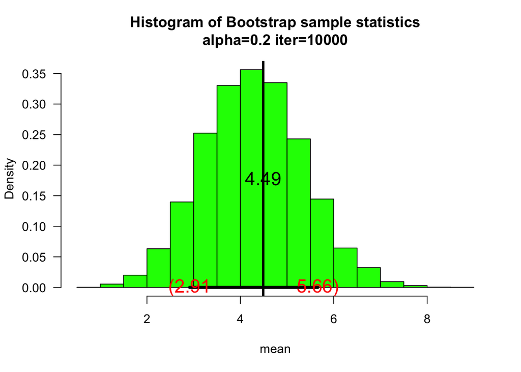

```r
set.seed(40); sam=rgamma(30,shape=2,scale=3)
c=myboot2(iter=10000,sam,fun="var",alpha=0.2, xlab="mean", col="pink")
```

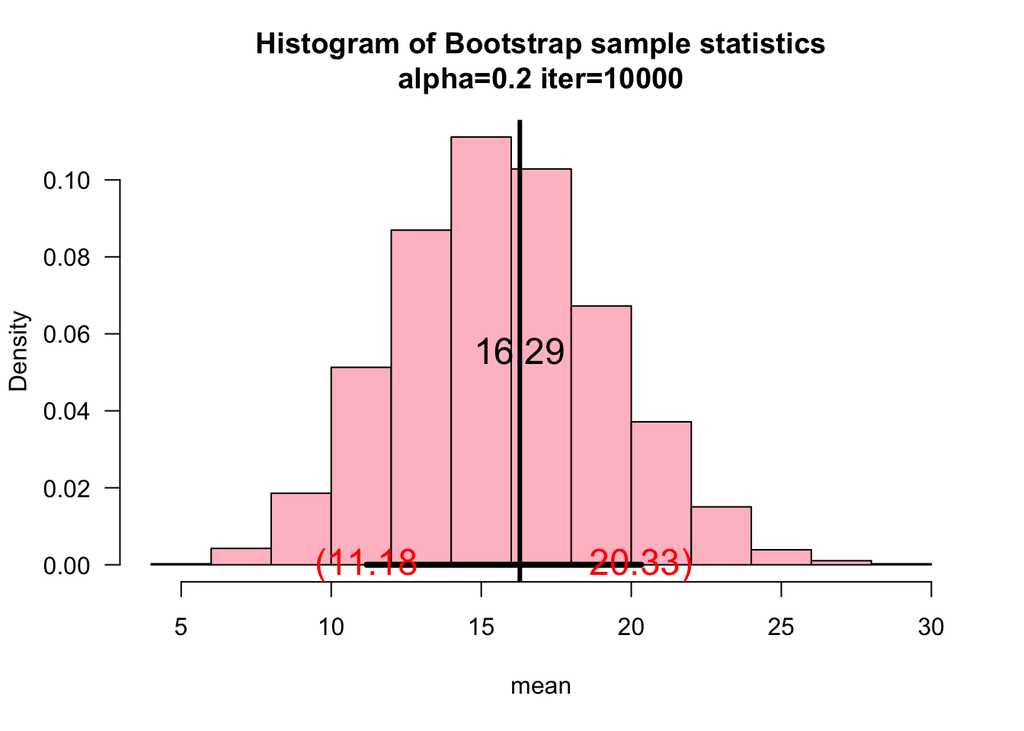

```r
set.seed(10); sam=rbeta(20,shape1=3,shape2=4)
d=myboot2(iter=10000,sam,fun="var",alpha=0.2, xlab="mean", col="orange")
```

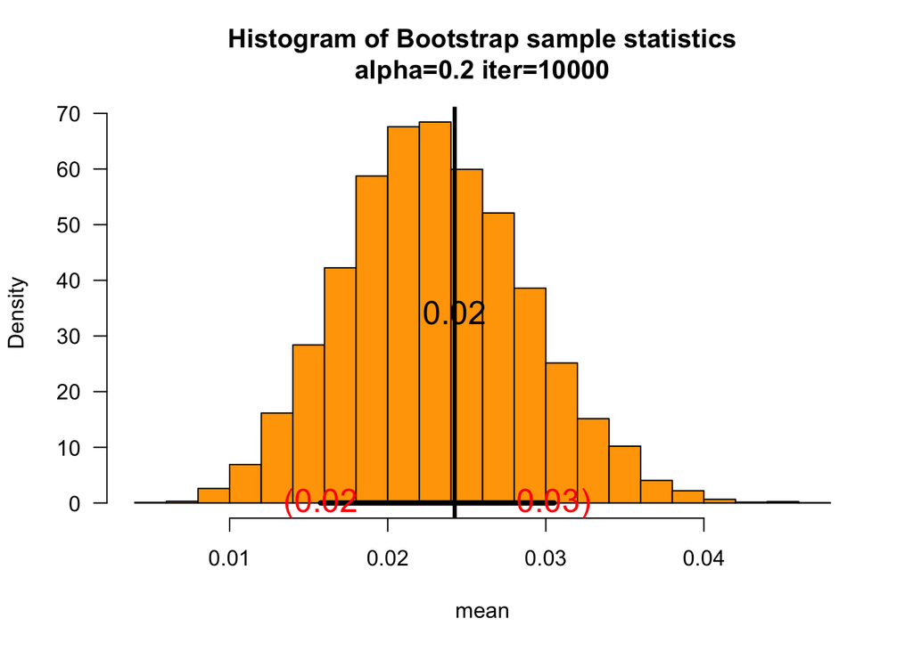

## Task 4

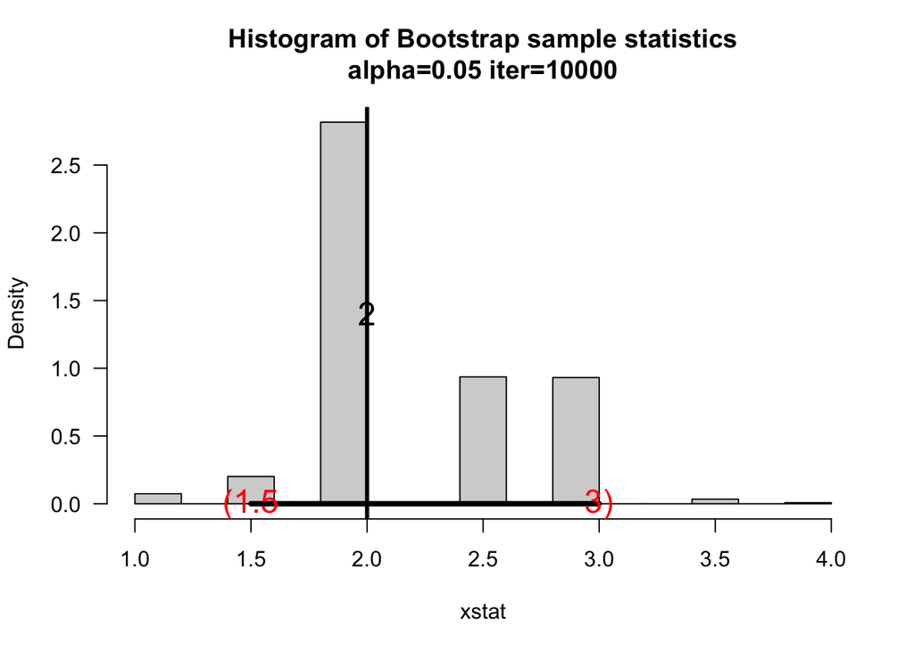

```r
myboot2<-function(iter=10000,x,fun="mean",alpha=0.05,cx=1.5,...){  #Notice where the ... is repeated in the code
n=length(x)   #sample size

y=sample(x,n*iter,replace=TRUE)
rs.mat=matrix(y,nr=n,nc=iter,byrow=TRUE)
xstat=apply(rs.mat,2,fun) # xstat is a vector and will have iter values in it
ci=quantile(xstat,c(alpha/2,1-alpha/2))# Nice way to form a confidence interval
# A histogram follows
# The object para will contain the parameters used to make the histogram
para=hist(xstat,freq=FALSE,las=1,
main=paste("Histogram of Bootstrap sample statistics","\n","alpha=",alpha," iter=",iter,sep=""),
...)

#mat will be a matrix that contains the data, this is done so that I can use apply()
mat=matrix(x,nr=length(x),nc=1,byrow=TRUE)

#pte is the point estimate
#This uses whatever fun is
pte=apply(mat,2,fun)
abline(v=pte,lwd=3,col="Black")# Vertical line
segments(ci[1],0,ci[2],0,lwd=4)      #Make the segment for the ci
text(ci[1],0,paste("(",round(ci[1],2),sep=""),col="Red",cex=cx)
text(ci[2],0,paste(round(ci[2],2),")",sep=""),col="Red",cex=cx)

# plot the point estimate 1/2 way up the density
text(pte,max(para$density)/2,round(pte,2),cex=cx)
return(list(ci=ci, fun=fun,x=x,xstat=xstat))

}
sam=c(1,1,1,2,2,2,2,3,3,3,4,4)
a=myboot2(x=sam,fun="median")
```

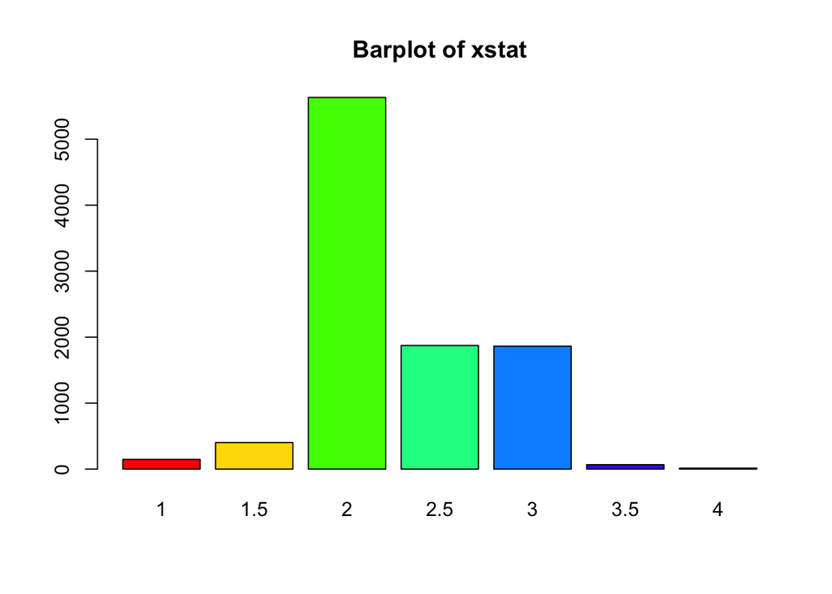

```r
tab <- table(a$xstat)
barplot(tab,main= "Barplot of xstat",col= rainbow(7))
```

The bootstrap interval estimate is (1.5,3)

## Task 5

### 95% estimatw intervals

```r
funtask5 = function(x){
  mean(x)/median(x)
}
```

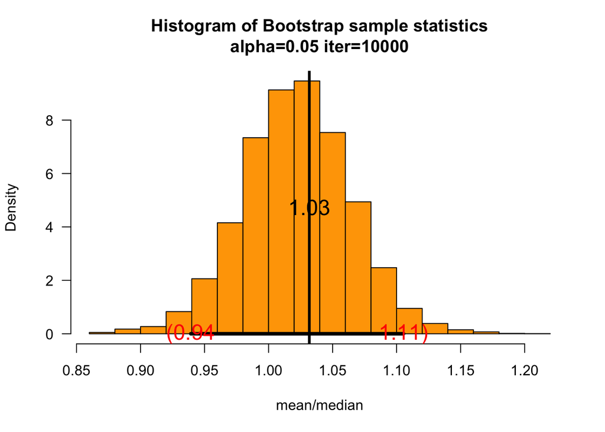

```r
#A
set.seed(39); sam=rnorm(25,mean=25,sd=10)
myboot2<-function(iter=10000,x,fun="mean",alpha=0.05,cx=1.5,...){  #Notice where the ... is repeated in the code
n=length(x)   #sample size

y=sample(x,n*iter,replace=TRUE)
rs.mat=matrix(y,nr=n,nc=iter,byrow=TRUE)
xstat=apply(rs.mat,2,fun) # xstat is a vector and will have iter values in it
ci=quantile(xstat,c(alpha/2,1-alpha/2))# Nice way to form a confidence interval
# A histogram follows
# The object para will contain the parameters used to make the histogram
para=hist(xstat,freq=FALSE,las=1,
main=paste("Histogram of Bootstrap sample statistics","\n","alpha=",alpha," iter=",iter,sep=""),
...)

#mat will be a matrix that contains the data, this is done so that I can use apply()
mat=matrix(x,nr=length(x),nc=1,byrow=TRUE)

#pte is the point estimate
#This uses whatever fun is
pte=apply(mat,2,fun)
abline(v=pte,lwd=3,col="Black")# Vertical line
segments(ci[1],0,ci[2],0,lwd=4)      #Make the segment for the ci
text(ci[1],0,paste("(",round(ci[1],2),sep=""),col="Red",cex=cx)
text(ci[2],0,paste(round(ci[2],2),")",sep=""),col="Red",cex=cx)

# plot the point estimate 1/2 way up the density
text(pte,max(para$density)/2,round(pte,2),cex=cx)
return(list(ci=ci, fun=fun,x=x))
}
a=myboot2(iter=10000,x = sam,fun="funtask5",alpha=0.05, xlab="mean/median", col="orange")
```

```r
#b
set.seed(30); sam=rchisq(20,df=3)
b=myboot2(iter=10000,x = sam,fun="funtask5",alpha=0.05, xlab="mean/median", col="green")
```

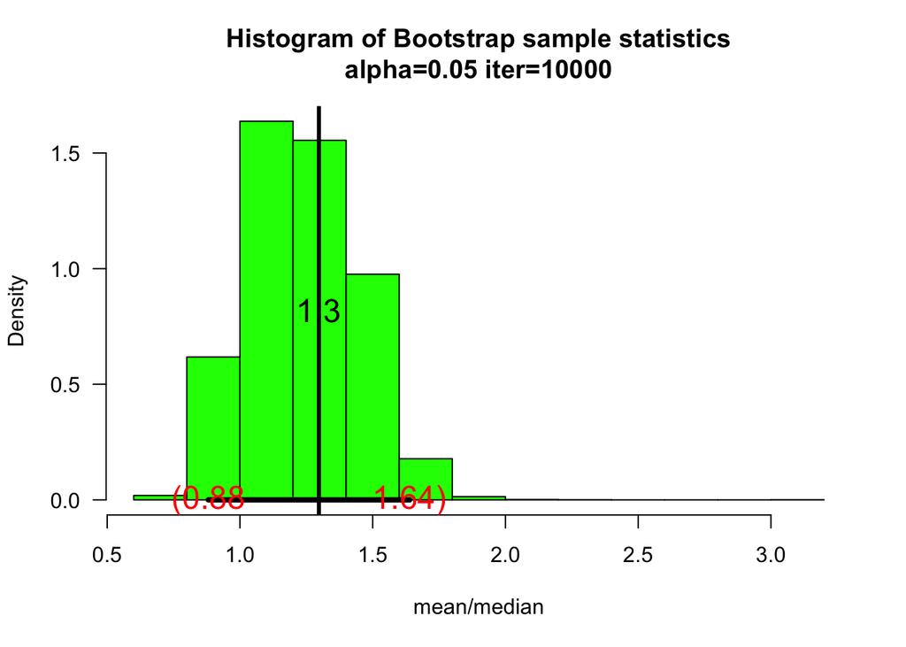

```r
#c
set.seed(40); sam=rgamma(30,shape=2,scale=3)
c=myboot2(iter=10000,x = sam,fun="funtask5",alpha=0.05, xlab="mean/median", col="blue")
```

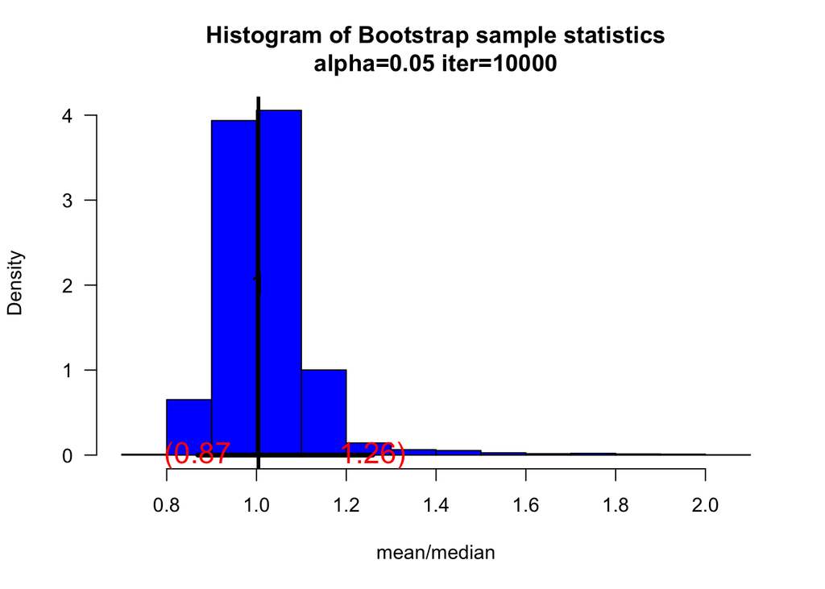

```r
#D
set.seed(10); sam=rbeta(20,shape1=3,shape2=4)
d=myboot2(iter=10000,x = sam,fun="funtask5",alpha=0.05, xlab="mean/median", col="purple")
```

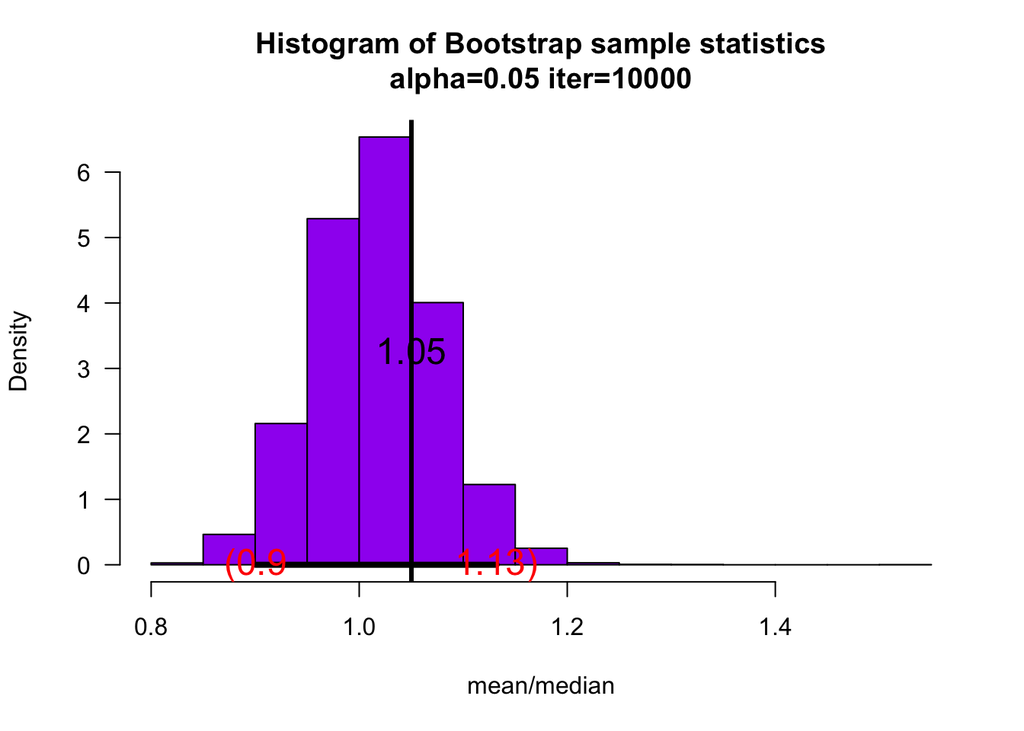

### 70% estimate intervals

```r
#A
set.seed(39); sam=rnorm(25,mean=25,sd=10)
a=myboot2(iter=10000,x = sam,fun="funtask5",alpha=0.3, xlab="mean/median", col="ORANGE")
```

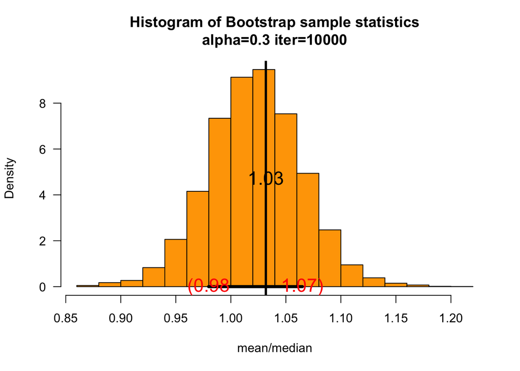

```r
#b
set.seed(30); sam=rchisq(20,df=3)
b=myboot2(iter=10000,x = sam,fun="funtask5",alpha=0.3, xlab="mean/median", col="green")
```

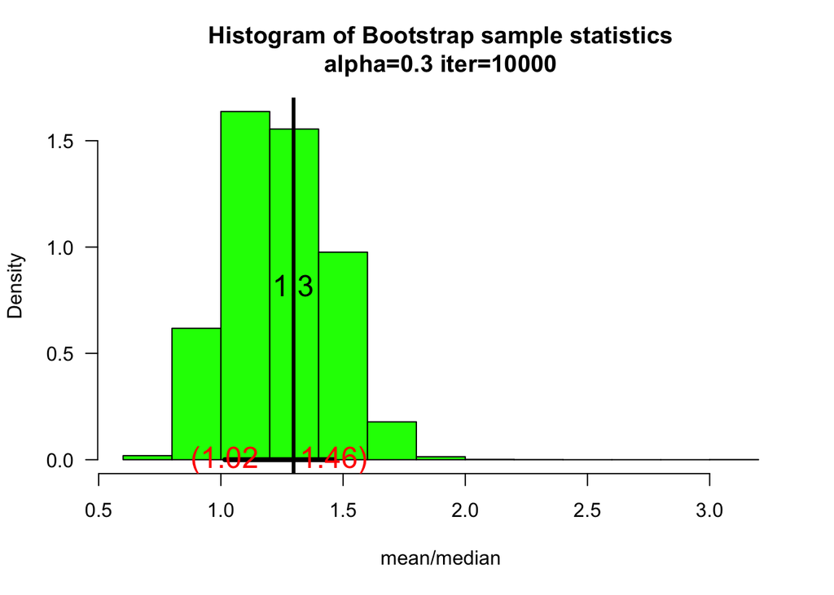

```r
#c
set.seed(40); sam=rgamma(30,shape=2,scale=3)
c=myboot2(iter=10000,x = sam,fun="funtask5",alpha=0.3, xlab="mean/median", col="blue")
```

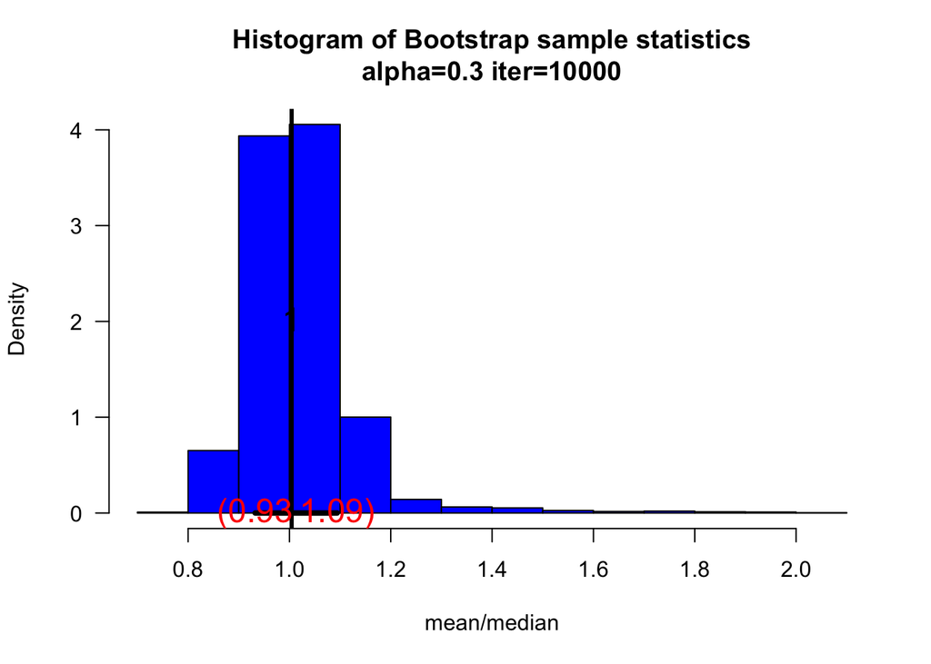

```r
#D
set.seed(10); sam=rbeta(20,shape1=3,shape2=4)
d=myboot2(iter=10000,x = sam,fun="funtask5",alpha=0.3, xlab="mean/median", col="purple")
```

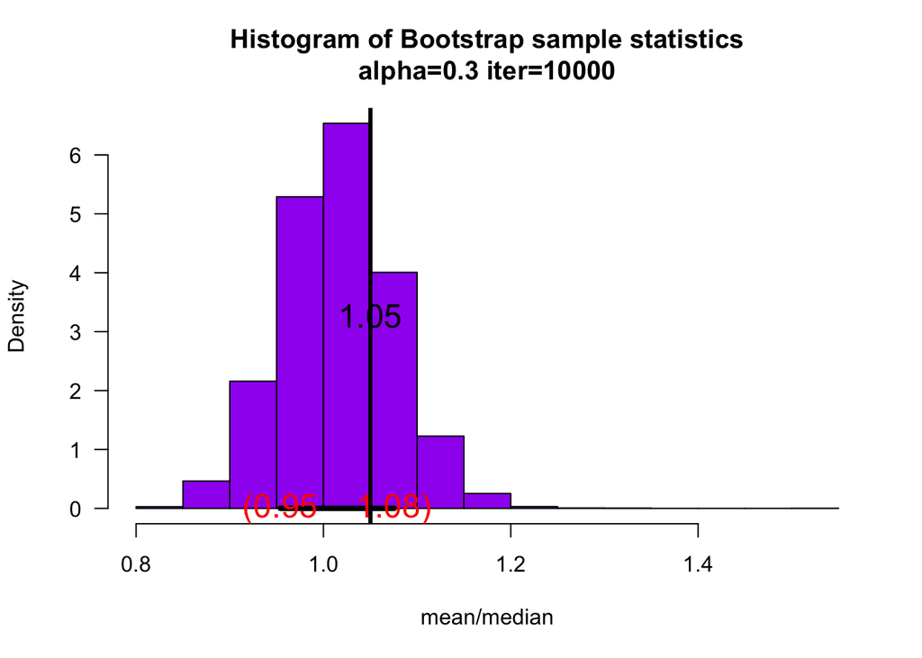

## Task 6

### Sample 4 distrubutions and 80% bootstrap intervals

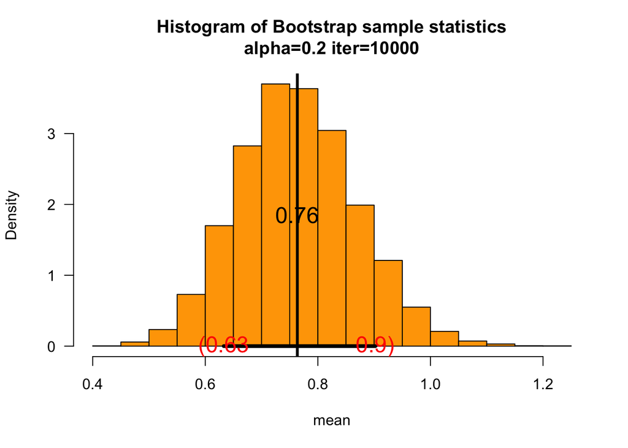

```
## $ci
##       10%       90%
## 0.6327686 0.9021334
##
## $fun
## [1] "mean"
##
## $x
##  [1] 0.3934405 2.1273943 0.7698423 0.2260014 0.8489292 1.5379952 0.8542133
##  [8] 0.7172083 0.0205490 0.1716599 1.0285342 0.7717114 0.6454220 1.0310959
## [15] 1.1172695 0.6520155 0.3523969 0.4565616 0.6721613 0.8760951
```

```r
#Weibull
set.seed(35)
samn = rweibull(20,shape=2,scale=1)

myboot2(iter = 10000, samn, fun = "mean", alpha = 0.2, xlab="mean", col= "orange")
```

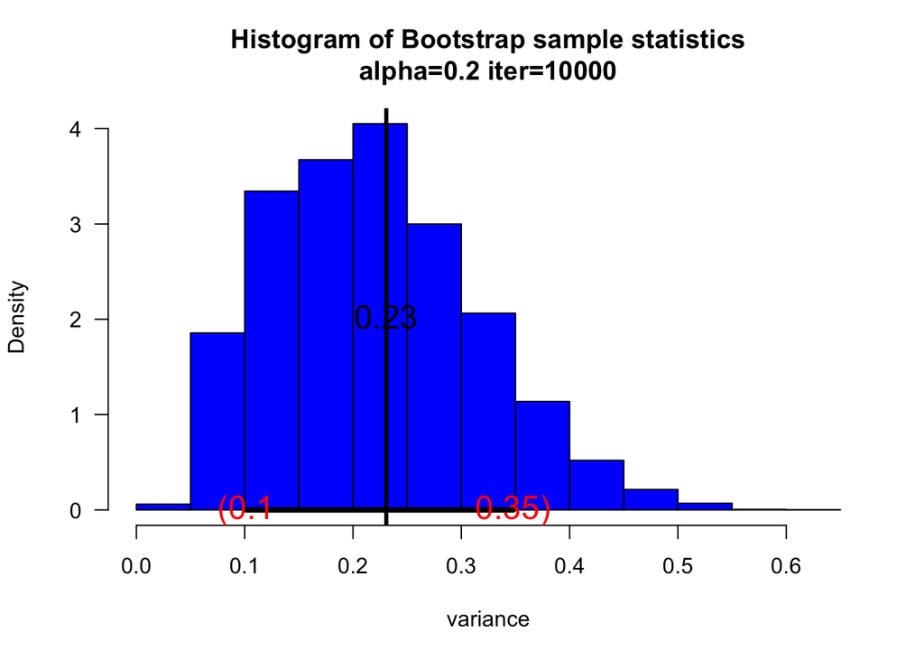

```
## $ci
##       10%       90%
## 0.1012293 0.3479678
##
## $fun
## [1] "var"
##
## $x
##  [1] 0.3934405 2.1273943 0.7698423 0.2260014 0.8489292 1.5379952 0.8542133
##  [8] 0.7172083 0.0205490 0.1716599 1.0285342 0.7717114 0.6454220 1.0310959
## [15] 1.1172695 0.6520155 0.3523969 0.4565616 0.6721613 0.8760951
```

```r
myboot2(iter = 10000, samn, fun = "var", alpha = 0.2, xlab="variance", col= "Blue")
```

```r
# Geometric
set.seed(35)
sam=rgeom(20,prob = 0.2)
sam
```

```
##  [1]  0 10  0  4  1  3  1  9 11  6  1  3  7  3 10  0  6  1  1  0
```

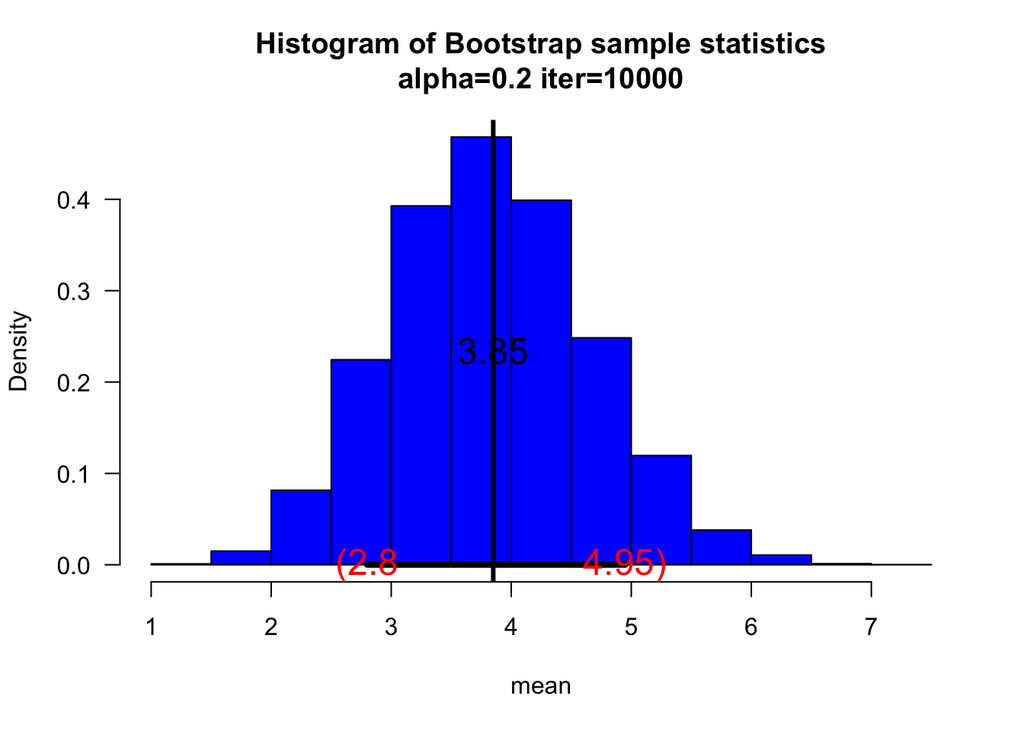

```
## $ci
##  10%  90%
## 2.80 4.95
##
## $fun
## [1] "mean"
##
## $x
##  [1]  0 10  0  4  1  3  1  9 11  6  1  3  7  3 10  0  6  1  1  0
```

```r
myboot2(iter = 10000, sam, fun = "mean", alpha = 0.2, xlab="mean", col= "blue")
```

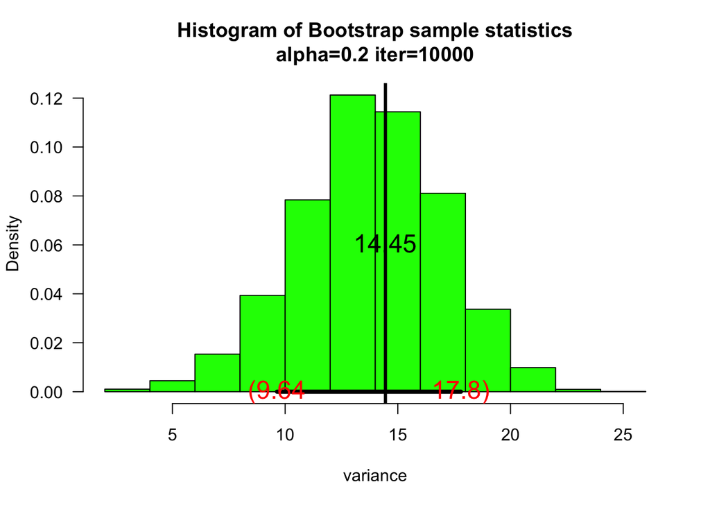

```
## $ci
##       10%       90%
##  9.641053 17.800000
##
## $fun
## [1] "var"
##
## $x
##  [1]  0 10  0  4  1  3  1  9 11  6  1  3  7  3 10  0  6  1  1  0
```

```r
myboot2(iter = 10000, sam, fun = "var", alpha = 0.2, xlab="variance", col= "green")
```

```r
# binomial
set.seed(35)
samb=rbinom(20, size =10, prob=0.4)
samb
```

```
##  [1] 6 1 4 7 4 2 4 4 9 7 3 4 5 3 3 5 6 5 5 4
```

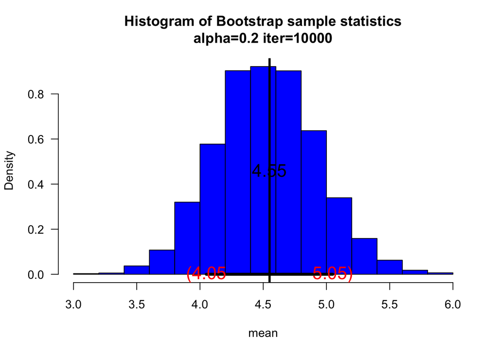

```
## $ci
##  10%  90%
## 4.05 5.05
##
## $fun
## [1] "mean"
##
## $x
##  [1] 6 1 4 7 4 2 4 4 9 7 3 4 5 3 3 5 6 5 5 4
```

```r
myboot2(iter = 10000, samb, fun = "mean", alpha = 0.2, xlab="mean", col= "blue")
```

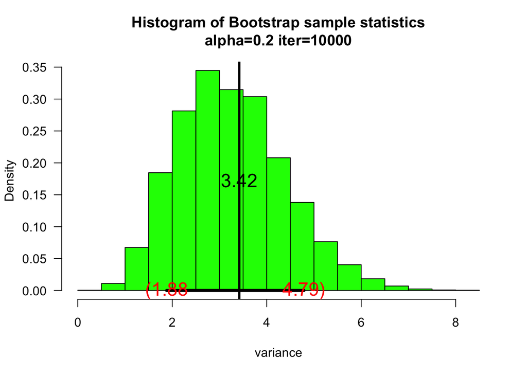

```
## $ci
##      10%      90%
## 1.881579 4.787105
##
## $fun
## [1] "var"
##
## $x
##  [1] 6 1 4 7 4 2 4 4 9 7 3 4 5 3 3 5 6 5 5 4
```

```r
myboot2(iter = 10000, samb, fun = "var", alpha = 0.2, xlab="variance", col= "green")
```

```r
#exponential
set.seed(35)
same=rexp(20,rate = 1)
same
```

```
##  [1] 0.007503999 0.065092755 1.107556704 0.240653906 1.074599726 0.841126549
##  [7] 0.307377221 0.441174963 1.175243826 0.343926232 1.185721353 1.599885711
## [13] 0.019517418 2.977286018 0.889047546 0.612549793 0.560796773 1.152226590
## [19] 0.554438443 0.160179988
```

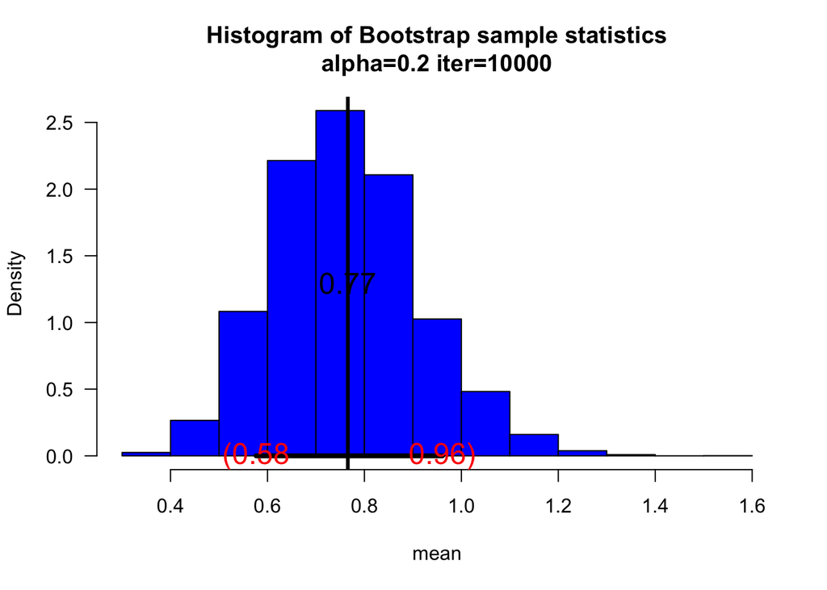

```
## $ci
##       10%       90%
## 0.5766312 0.9611088
##
## $fun
## [1] "mean"
##
## $x
##  [1] 0.007503999 0.065092755 1.107556704 0.240653906 1.074599726 0.841126549
##  [7] 0.307377221 0.441174963 1.175243826 0.343926232 1.185721353 1.599885711
## [13] 0.019517418 2.977286018 0.889047546 0.612549793 0.560796773 1.152226590
## [19] 0.554438443 0.160179988
```

```r
myboot2(iter = 10000, same, fun = "mean", alpha = 0.2, xlab="mean", col= "blue")
```

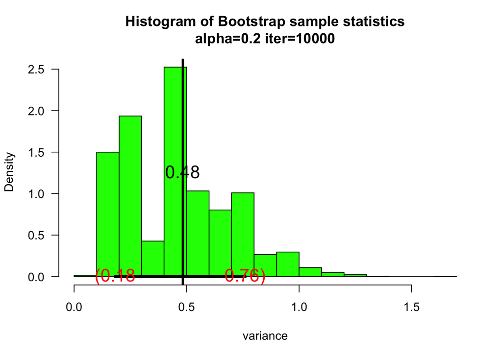

```
## $ci
##       10%       90%
## 0.1820493 0.7607617
##
## $fun
## [1] "var"
##
## $x
##  [1] 0.007503999 0.065092755 1.107556704 0.240653906 1.074599726 0.841126549
##  [7] 0.307377221 0.441174963 1.175243826 0.343926232 1.185721353 1.599885711
## [13] 0.019517418 2.977286018 0.889047546 0.612549793 0.560796773 1.152226590
## [19] 0.554438443 0.160179988
```

```r
myboot2(iter = 10000, same, fun = "var", alpha = 0.2, xlab="variance", col= "green")
```

## Task 7

### Create bootstrap intervals

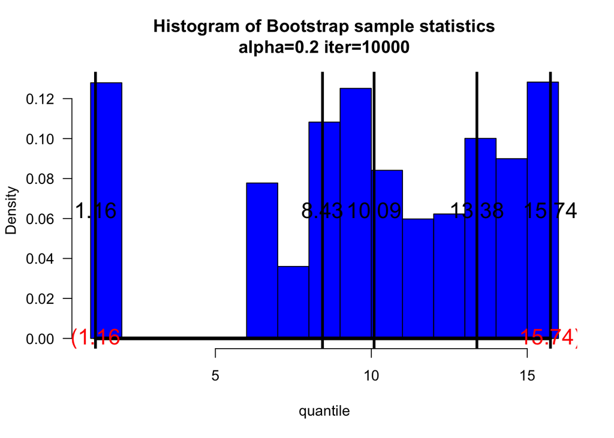

```
## $ci
##       10%       90%
##  1.155378 15.743750
##
## $fun
## [1] "quantile"
##
## $x
##  [1] 15.743750  9.011543  8.487107 12.302301  8.274762 10.033130 14.601905
##  [8] 11.648501 13.546594 13.330691  9.641557  6.760229  6.716014 13.997038
## [15]  9.458889 10.143532  1.155378 11.836486  7.832403 14.664414
```

```r
set.seed(68); sam=rnorm(20,mean = 10,sd=4)
myboot2(iter = 10000, sam, fun = "quantile", alpha = 0.2, xlab="quantile", col= "blue")
```

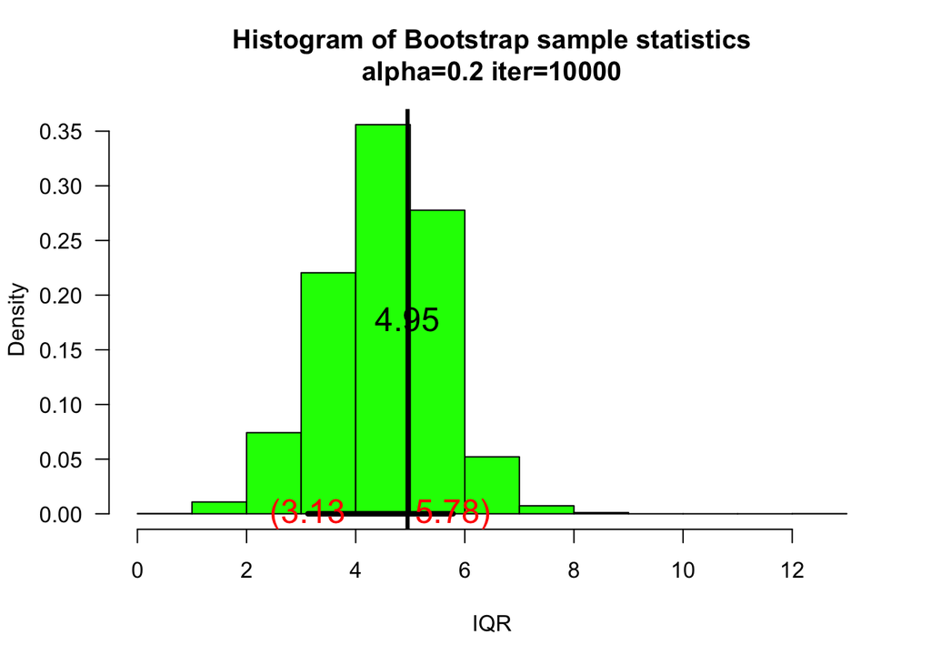

```
## $ci
##      10%      90%
## 3.125593 5.783980
##
## $fun
## [1] "IQR"
##
## $x
##  [1] 15.743750  9.011543  8.487107 12.302301  8.274762 10.033130 14.601905
##  [8] 11.648501 13.546594 13.330691  9.641557  6.760229  6.716014 13.997038
## [15]  9.458889 10.143532  1.155378 11.836486  7.832403 14.664414
```

```r
myboot2(iter = 10000, sam, fun = "IQR", alpha = 0.2, xlab="IQR", col= "GREEN")
```

### 95% Confidence interval

Given mean = 10 and sd =4, then σ/√n = 4/√2= 0.8944 and

```r
qnorm(1-0.05/2, mean = 0,sd=1)
```

```
## [1] 1.959964
```

The interval given by:(8.247,11.753)

```r
10-1.959964*0.8944
```

```
## [1] 8.247008
```

```r
10+1.959964*0.8944
```

```
## [1] 11.75299
```

### 95% bootstrap interval

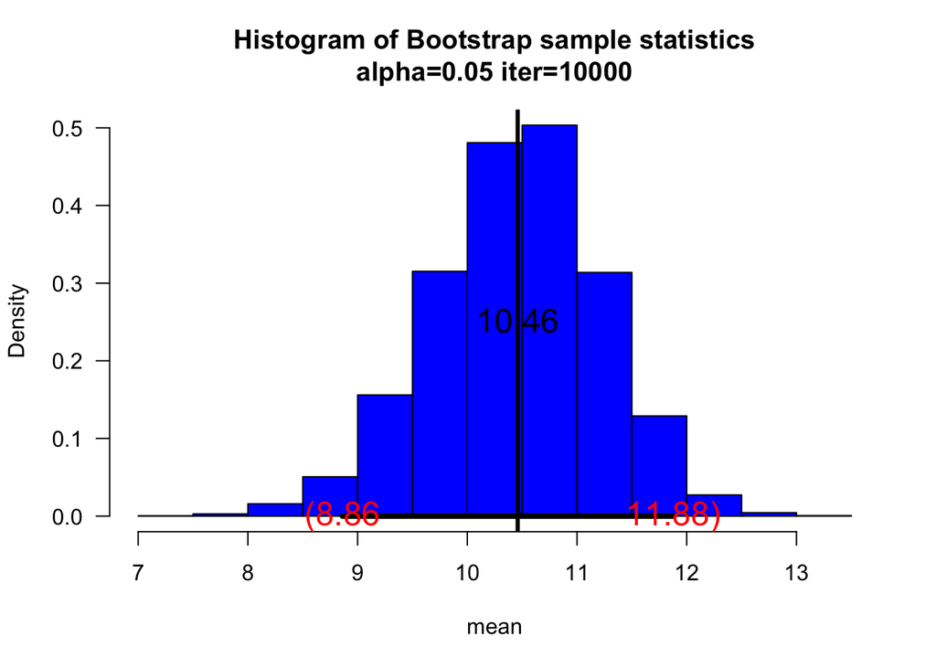

```
## $ci
##      2.5%     97.5%
##  8.862478 11.878680
##
## $fun
## [1] "mean"
##
## $x
##  [1] 15.743750  9.011543  8.487107 12.302301  8.274762 10.033130 14.601905
##  [8] 11.648501 13.546594 13.330691  9.641557  6.760229  6.716014 13.997038
## [15]  9.458889 10.143532  1.155378 11.836486  7.832403 14.664414
```

```r
set.seed(68); sam=rnorm(20,mean = 10,sd=4)
myboot2(iter = 10000, sam, fun = "mean", alpha = 0.05, xlab="mean", col= "blue")
```

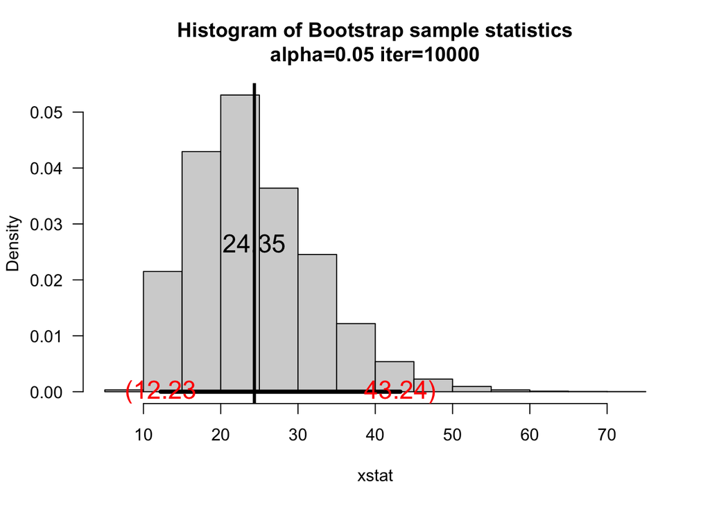

```r
ddt=read.csv("DDT-1.csv")
MATH4753SHON2024::myboot2(x=ddt$DDT)
```

## Task 9

### Extra

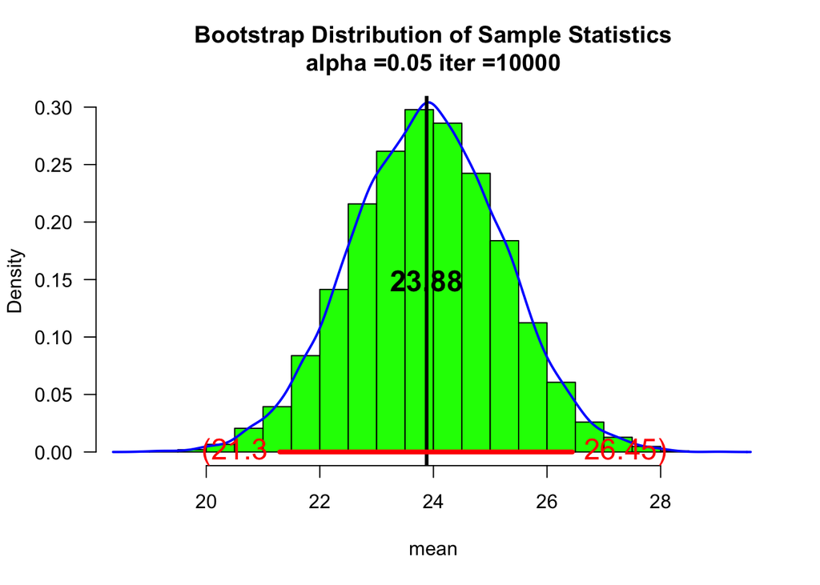

```r
myboot2 <- function(iter = 10000, x, fun = "mean", alpha = 0.05, cx = 1.5, ...) {
  n <- length(x)  # sample size

  # Create bootstrap samples and calculate the statistic for each sample
  y <- sample(x, n * iter, replace = TRUE)
  rs.mat <- matrix(y, nrow = n, ncol = iter, byrow = TRUE)
  xstat <- apply(rs.mat, 2, fun)  # vector of sample statistics
  ci <- quantile(xstat, c(alpha / 2, 1 - alpha / 2))  # confidence interval

  # Histogram with density curve overlay
  para <- hist(xstat, freq = FALSE, las = 1,
               main = paste("Bootstrap Distribution of Sample Statistics",
                            "\n", "alpha =", alpha, " iter =", iter, sep = ""),
               ...)  # Now relies on ... for 'col' and other arguments

  lines(density(xstat), col = "blue", lwd = 2)  # density curve

  # Create a matrix for the observed data and calculate the point estimate
  mat <- matrix(x, nrow = length(x), ncol = 1, byrow = TRUE)
  pte <- apply(mat, 2, fun)

  # Add annotations: point estimate line, confidence interval segments, labels
  abline(v = pte, lwd = 3, col = "black")  # point estimate
  segments(ci[1], 0, ci[2], 0, lwd = 4, col = "red")  # confidence interval
  text(ci[1], 0, paste("(", round(ci[1], 2), sep = ""), col = "red", cex = cx, pos = 2)
  text(ci[2], 0, paste(round(ci[2], 2), ")", sep = ""), col = "red", cex = cx, pos = 4)

  # Annotate point estimate on histogram
  text(pte, max(para$density) / 2, round(pte, 2), col = "black", cex = cx, font = 2)

  # Make output invisible but accessible if needed
  invisible(list(ci = ci, fun = fun, x = x))
}
set.seed(39)
sam = rnorm(25, mean = 25, sd = 10)
a = myboot2(iter = 10000, sam, fun = "mean", alpha = 0.05, xlab = "mean", col = "green")
```